# FIA - NLS Models: Biomass vs. Stand Age, G-Reconciled, Temporally-balanced, No Harvest – Log-Normal

JAH

2022-10-27

# Background

This document has *LOG-NORMAL* regression fits using the Michaelis-Menten functional form to USFS FIA (United States Forest Service Forest Inventory & Analysis) **biomass vs. stand age** relationships. We calculated the biomass of each FIA plot by summing alive tree biomass (as reported by FIA). Stand age is also reported by FIA, using tree-core age estimates from two trees from the dominant size class of the FIA plot.

Model selection is used to determine the best fitting models including $\phi$: the effect of changing climate (quantified as $\Delta PDSI$, or the difference in the Palmer drought severity index from June - August for the 10 years preceding the biomass measurement and the 1960-1989 period) and $\alpha$: the biomass compensation effect due to lost biomass (natural mortality or harvest).

**model 1: simple model** $B = (1 + (yr-1990)* ge/100) \times \left(a + b \cdot \exp{ - \left[ \frac{ \log \left(StdAge_{t2} /c \right)} {d} \right]} ^2 \right)$

**model 2: phi model** $B = (1 + (yr-1990)* ge/100) \times (1 + \phi \cdot \Delta PDSI) \times \left(a + b \cdot \exp{ - \left[ \frac{ \log \left(StdAge_{t2} /c \right)} {d} \right]} ^2 \right)$

**model 3: phi-alpha model** $B = (1 + (yr-1990)* ge/100) \times (1 + \phi \cdot \Delta PDSI) \times (1 - \alpha \cdot B_l) \times \left(a + b \cdot \exp{ - \left[ \frac{ \log \left(StdAge_{t2} /c \right)} {d} \right]} ^2 \right)$

*Note:*

*Note:*

*This analysis only uses plot biomass data from the same plot locations and measurement intervals for which we also have data on biomass growth (which is used in the* **growth vs. biomass analysis** *). We use the second of the two plot measurements comprising a $G$ interval*

*This analysis further excludes plots were timber harvest occurred*

Below the model fitting procedure is implemented by ecoprovince:

# 211 - Northeastern Mixed Forest

## model selection 1

```
## Error in eval(extras, data, env) : object 'P_211' not found
## Error in eval(extras, data, env) : object 'P_211' not found
##   model      AIC
## 1     1       NA
## 2     2       NA
## 3     3 39988.49
```

```
##
## Formula: B_plt_t2_MgHa ~ (1 + (MEASTIME_t2 - 1990) * ge/100) * (1 + phi *
##     DeltaPDSI) * (1 - alpha * B_L_prop) * (a + b * exp(-((log(STDAGE_t2/c))/d)^2))
##
## Parameters:
##        Estimate Std. Error t value Pr(>|t|)
## ge    8.265e-01  2.708e-01   3.052  0.00229 **
## phi   5.462e-03  7.624e-03   0.716  0.47378
## alpha 1.178e+00  7.124e-02  16.530  < 2e-16 ***
## a     3.897e+01  2.436e+00  15.995  < 2e-16 ***
## b     1.081e+02  6.473e+00  16.705  < 2e-16 ***
## c     1.142e+02  5.286e+00  21.601  < 2e-16 ***
## d     9.126e-01  5.139e-02  17.757  < 2e-16 ***
## ---
## Signif. codes:  0 '***' 0.001 '**' 0.01 '*' 0.05 '.' 0.1 ' ' 1
##
## Residual standard error: 0.4511 on 3706 degrees of freedom
##
## Algorithm "port", convergence message: relative convergence (4)
##   (1 observation deleted due to missingness)
```

### summary

- simple model: does not fit
- phi model: does not fit
- phi-alpha model: fits

## plot residuals

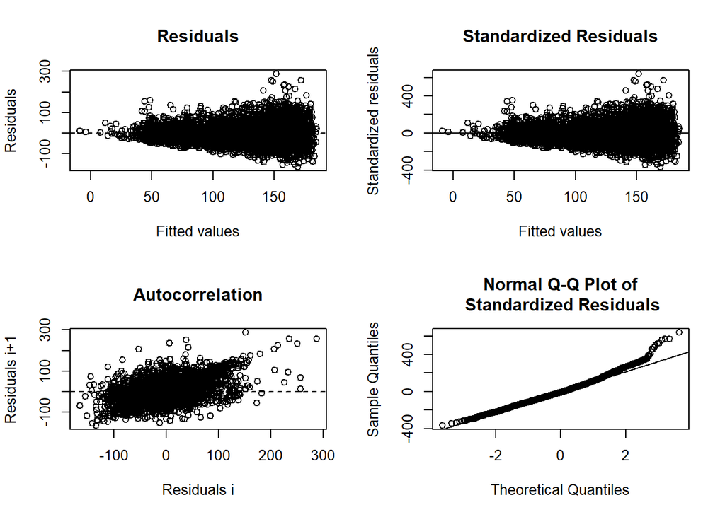

```
##
## ------
##  Shapiro-Wilk normality test
##
## data:  stdres
## W = 0.98683, p-value < 2.2e-16
##
##
## ------
```

```
##
##  Runs Test
##
## data:  as.factor(run)
## Standard Normal = -26.755, p-value < 2.2e-16
## alternative hypothesis: two.sided
```

## predict and plot

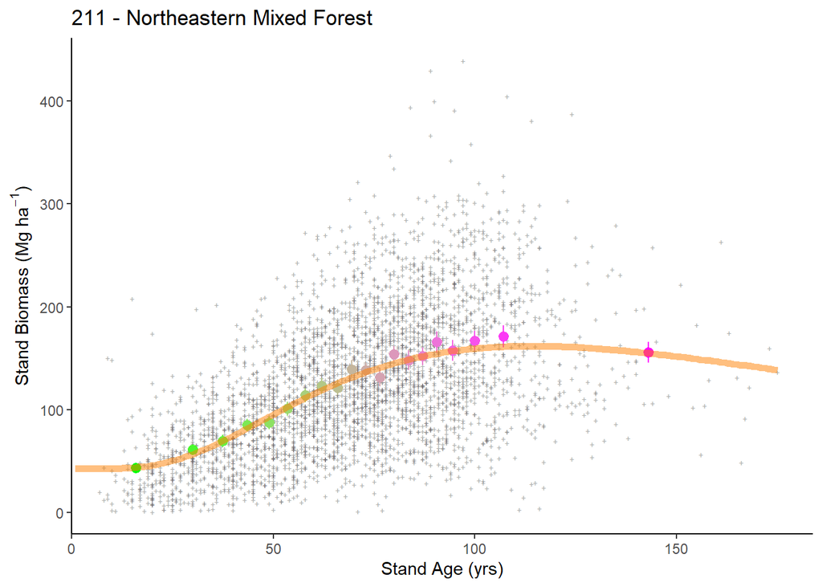

## plotting 2

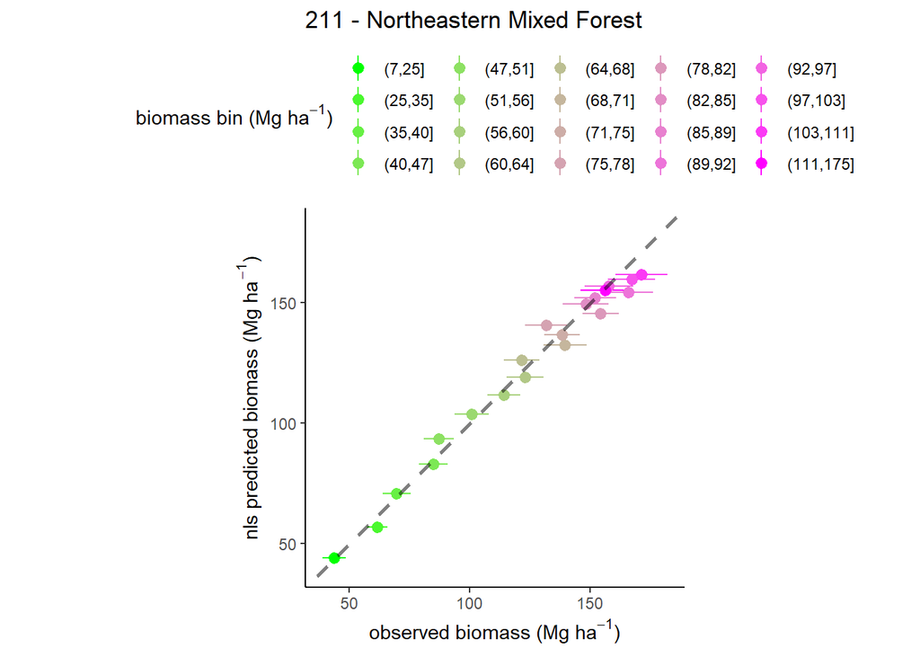

# 212 - Laurentian Mixed Forest

## model selection 1

[output not shown]

```
##
## Formula: B_plt_t2_MgHa ~ (1 + (MEASTIME_t2 - 1990) * ge/100) * (1 + phi *
##     DeltaPDSI) * (1 - alpha * B_L_prop) * (a + b * exp(-((log(STDAGE_t2/c))/d)^2))
##
## Parameters:
##        Estimate Std. Error t value Pr(>|t|)
## ge    7.836e-01  1.604e-01   4.885 1.05e-06 ***
## phi   3.448e-03  4.956e-03   0.696    0.487
## alpha 8.931e-01  4.274e-02  20.894  < 2e-16 ***
## a     1.932e+01  1.101e+00  17.540  < 2e-16 ***
## b     7.595e+01  2.934e+00  25.884  < 2e-16 ***
## c     1.149e+02  5.043e+00  22.790  < 2e-16 ***
## d     1.333e+00  5.216e-02  25.558  < 2e-16 ***
## ---
## Signif. codes:  0 '***' 0.001 '**' 0.01 '*' 0.05 '.' 0.1 ' ' 1
##
## Residual standard error: 0.5622 on 9644 degrees of freedom
##
## Algorithm "port", convergence message: relative convergence (4)
##   (7 observations deleted due to missingness)
```

### summary

- simple model: fits
- phi model: fits
- phi-alpha model: fits

## plot residuals

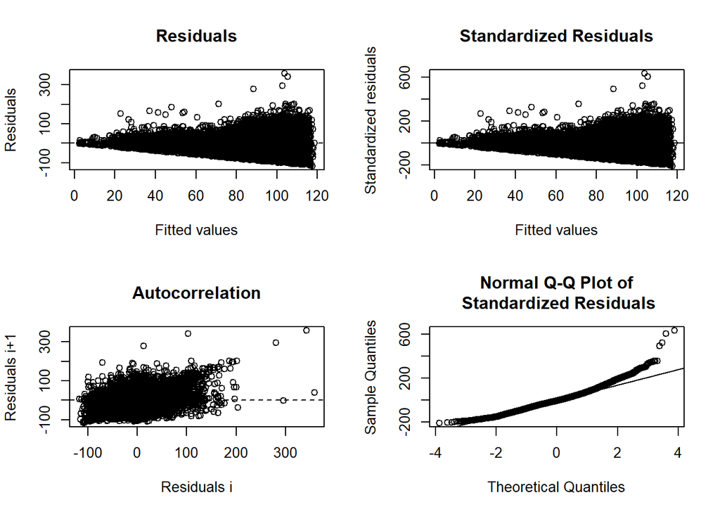

## predict and plot

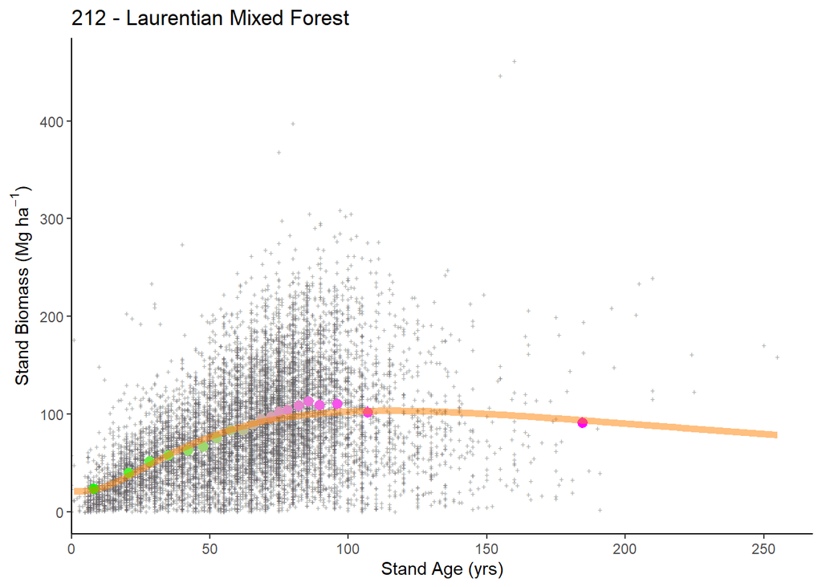

## plotting 2

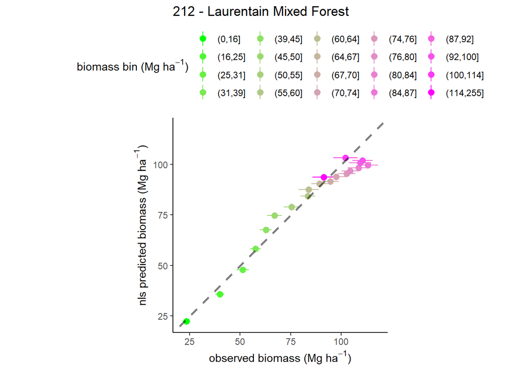

# 221 - Eastern Broadleaf Forest

## model selection 1

```
## Analysis of Variance Table
##
## Model 1: B_plt_t2_MgHa ~ (1 + (MEASTIME_t2 - 1990) * ge/100) * (a + b * exp(-((log(STDAGE_t2/c))/d)^2))
## Model 2: B_plt_t2_MgHa ~ (1 + (MEASTIME_t2 - 1990) * ge/100) * (1 + phi * DeltaPDSI) * (a + b * exp(-((log(STDAGE_t2/c))/d)^2))
## Model 3: B_plt_t2_MgHa ~ (1 + (MEASTIME_t2 - 1990) * ge/100) * (1 + phi * DeltaPDSI) * (1 - alpha * B_L_prop) * (a + b * exp(-((log(STDAGE_t2/c))/d)^2))
##   Res.Df Res.Sum Sq Df Sum Sq F value Pr(>F)
## 1   4380     678.31
## 2   4379     678.31  1  0.000   0.000 0.9999
## 3   4372     634.19  7 44.123  43.454 <2e-16 ***
## ---
## Signif. codes:  0 '***' 0.001 '**' 0.01 '*' 0.05 '.' 0.1 ' ' 1
##   model      AIC
## 1     1 47834.51
## 2     2 47836.51
## 3     3 47494.43
```

```
##
## Formula: B_plt_t2_MgHa ~ (1 + (MEASTIME_t2 - 1990) * ge/100) * (1 + phi *
##     DeltaPDSI) * (1 - alpha * B_L_prop) * (a + b * exp(-((log(STDAGE_t2/c))/d)^2))
##
## Parameters:
##        Estimate Std. Error t value Pr(>|t|)
## ge    6.368e-01  1.777e-01   3.585 0.000341 ***
## phi   0.000e+00  5.919e-03   0.000 1.000000
## alpha 9.290e-01  5.126e-02  18.122  < 2e-16 ***
## a     2.783e+01  3.563e+00   7.810 7.13e-15 ***
## b     1.510e+02  9.203e+00  16.413  < 2e-16 ***
## c     1.362e+02  1.190e+01  11.445  < 2e-16 ***
## d     1.352e+00  9.195e-02  14.700  < 2e-16 ***
## ---
## Signif. codes:  0 '***' 0.001 '**' 0.01 '*' 0.05 '.' 0.1 ' ' 1
##
## Residual standard error: 0.3809 on 4372 degrees of freedom
##
## Algorithm "port", convergence message: relative convergence (4)
##   (7 observations deleted due to missingness)
```

### summary

- simple model: fits
- phi model: fits
- phi-alpha model: fits

## plot residuals

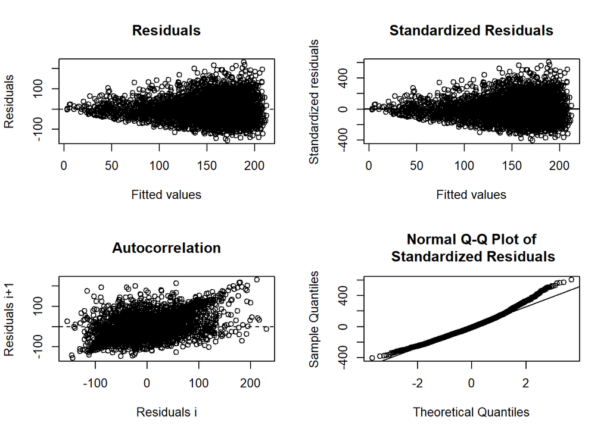

```
##
## ------
##  Shapiro-Wilk normality test
##
## data:  stdres
## W = 0.98445, p-value < 2.2e-16
##
##
## ------
```

```
##
##  Runs Test
##
## data:  as.factor(run)
## Standard Normal = -27.487, p-value < 2.2e-16
## alternative hypothesis: two.sided
```

## predict and plot

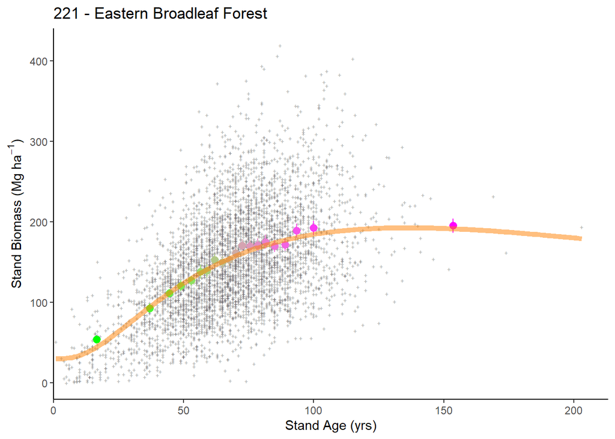

## plotting 2

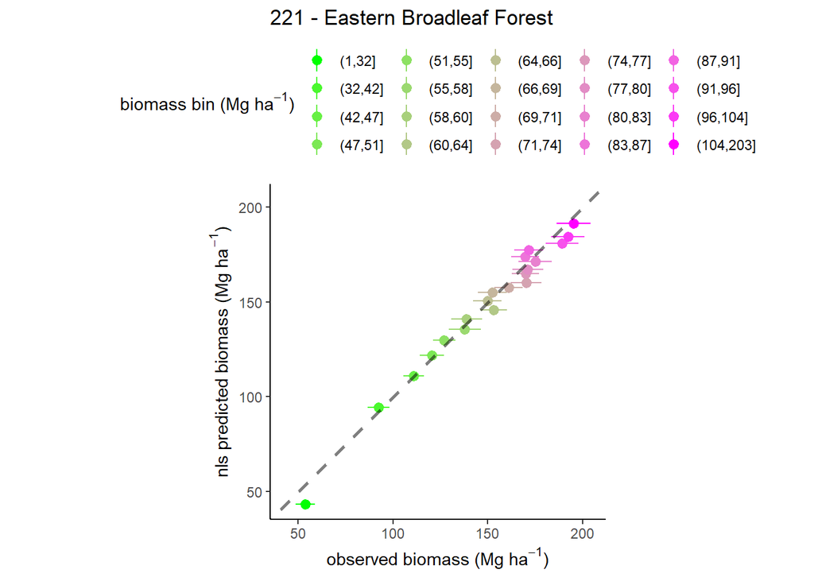

# 222 - Midwest Broadleaf Forest

## model selection 1

```
## Analysis of Variance Table
##
## Model 1: B_plt_t2_MgHa ~ (1 + (MEASTIME_t2 - 1990) * ge/100) * (a + b * exp(-((log(STDAGE_t2/c))/d)^2))
## Model 2: B_plt_t2_MgHa ~ (1 + (MEASTIME_t2 - 1990) * ge/100) * (1 + phi * DeltaPDSI) * (a + b * exp(-((log(STDAGE_t2/c))/d)^2))
## Model 3: B_plt_t2_MgHa ~ (1 + (MEASTIME_t2 - 1990) * ge/100) * (1 + phi * DeltaPDSI) * (1 - alpha * B_L_prop) * (a + b * exp(-((log(STDAGE_t2/c))/d)^2))
##   Res.Df Res.Sum Sq Df Sum Sq F value  Pr(>F)
## 1   2570     779.92
## 2   2569     777.93  1  1.987   6.561 0.01048 *
## 3   2566     724.43  3 53.494  63.160 < 2e-16 ***
## ---
## Signif. codes:  0 '***' 0.001 '**' 0.01 '*' 0.05 '.' 0.1 ' ' 1
```

```
##   model      AIC
## 1     1 27776.58
## 2     2 27772.02
## 3     3 27575.77
```

```
##
## Formula: B_plt_t2_MgHa ~ (1 + (MEASTIME_t2 - 1990) * ge/100) * (1 + phi *
##     DeltaPDSI) * (1 - alpha * B_L_prop) * (a + b * exp(-((log(STDAGE_t2/c))/d)^2))
##
## Parameters:
##        Estimate Std. Error t value Pr(>|t|)
## ge      0.18610    0.28761   0.647  0.51765
## phi     0.04329    0.01361   3.179  0.00149 **
## alpha   1.02495    0.06817  15.035  < 2e-16 ***
## a      23.34488    2.45900   9.494  < 2e-16 ***
## b     112.62745    7.53008  14.957  < 2e-16 ***
## c     104.08862    6.05749  17.183  < 2e-16 ***
## d       1.00816    0.06470  15.582  < 2e-16 ***
## ---
## Signif. codes:  0 '***' 0.001 '**' 0.01 '*' 0.05 '.' 0.1 ' ' 1
##
## Residual standard error: 0.5313 on 2566 degrees of freedom
##
## Algorithm "port", convergence message: relative convergence (4)
##   (3 observations deleted due to missingness)
```

### summary

- simple model: fits
- phi model: fits
- phi-alpha model: fits

## plot residuals

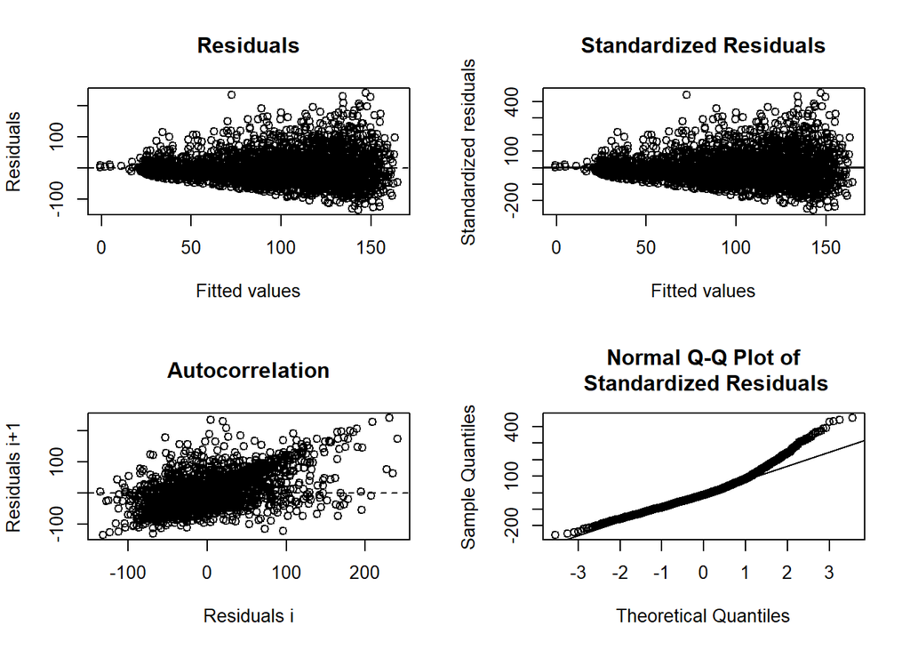

```
##
## ------
##  Shapiro-Wilk normality test
##
## data:  stdres
## W = 0.95683, p-value < 2.2e-16
##
##
## ------
```

```
##
##  Runs Test
##
## data:  as.factor(run)
## Standard Normal = -21.049, p-value < 2.2e-16
## alternative hypothesis: two.sided
```

## predict and plot

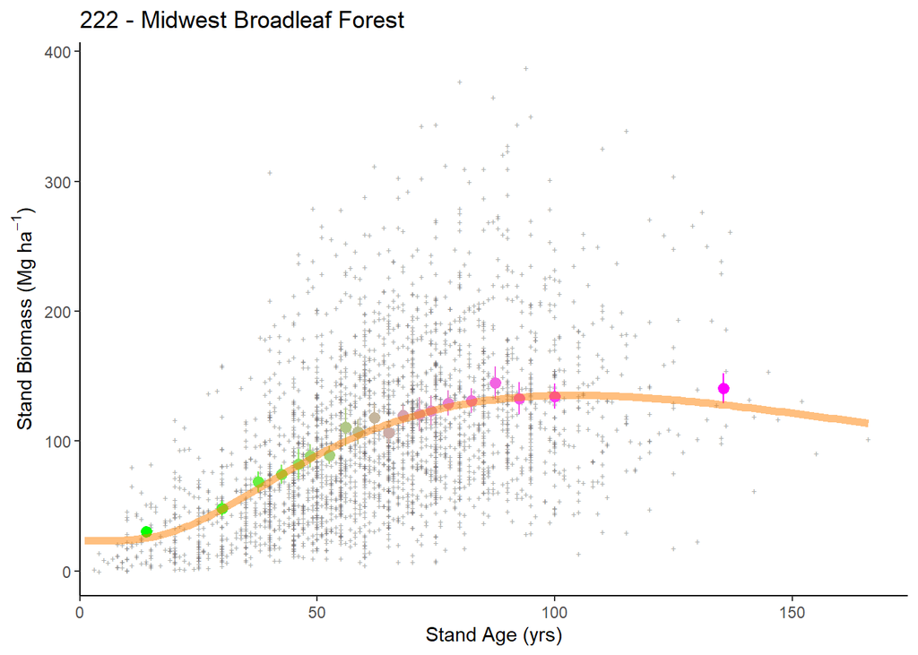

## plotting 2

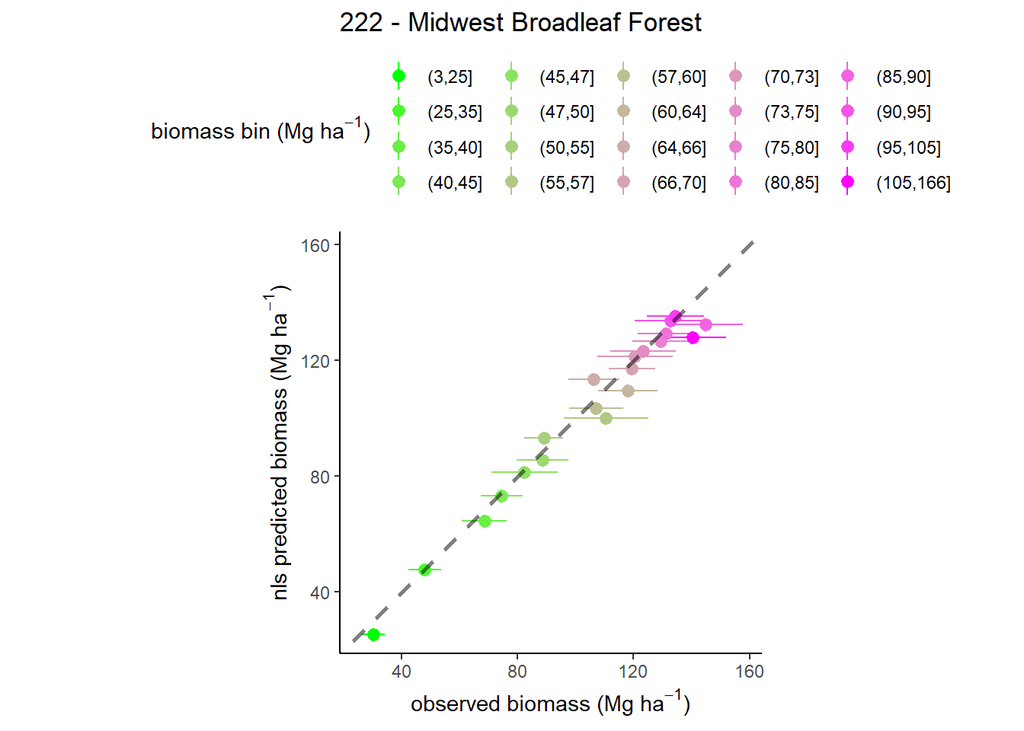

# 223 - Central Interior Broadleaf Forest

## model selection 1

```
## Analysis of Variance Table
##
## Model 1: B_plt_t2_MgHa ~ (1 + (MEASTIME_t2 - 1990) * ge/100) * (a + b * exp(-((log(STDAGE_t2/c))/d)^2))
## Model 2: B_plt_t2_MgHa ~ (1 + (MEASTIME_t2 - 1990) * ge/100) * (1 + phi * DeltaPDSI) * (a + b * exp(-((log(STDAGE_t2/c))/d)^2))
## Model 3: B_plt_t2_MgHa ~ (1 + (MEASTIME_t2 - 1990) * ge/100) * (1 + phi * DeltaPDSI) * (1 - alpha * B_L_prop) * (a + b * exp(-((log(STDAGE_t2/c))/d)^2))
##   Res.Df Res.Sum Sq Df Sum Sq F value Pr(>F)
## 1   5016     856.64
## 2   5015     856.64  1  0.000   0.000      1
## 3   5012     816.02  3 40.621  83.165 <2e-16 ***
## ---
## Signif. codes:  0 '***' 0.001 '**' 0.01 '*' 0.05 '.' 0.1 ' ' 1
##   model      AIC
## 1     1 52585.64
## 2     2 52587.64
## 3     3 52330.05
```

```
##
## Formula: B_plt_t2_MgHa ~ (1 + (MEASTIME_t2 - 1990) * ge/100) * (1 + phi *
##     DeltaPDSI) * (1 - alpha * B_L_prop) * (a + b * exp(-((log(STDAGE_t2/c))/d)^2))
##
## Parameters:
##        Estimate Std. Error t value Pr(>|t|)
## ge    3.534e-01  1.472e-01   2.402   0.0164 *
## phi   0.000e+00  6.907e-03   0.000   1.0000
## alpha 8.655e-01  5.208e-02  16.617   <2e-16 ***
## a     2.869e+01  3.378e+00   8.493   <2e-16 ***
## b     1.044e+02  5.410e+00  19.301   <2e-16 ***
## c     1.111e+02  7.099e+00  15.652   <2e-16 ***
## d     1.285e+00  8.611e-02  14.925   <2e-16 ***
## ---
## Signif. codes:  0 '***' 0.001 '**' 0.01 '*' 0.05 '.' 0.1 ' ' 1
##
## Residual standard error: 0.4035 on 5012 degrees of freedom
##
## Algorithm "port", convergence message: relative convergence (4)
##   (5 observations deleted due to missingness)
```

### summary

- simple model: fits
- phi model: fits
- phi-alpha model: fits

## plot residuals

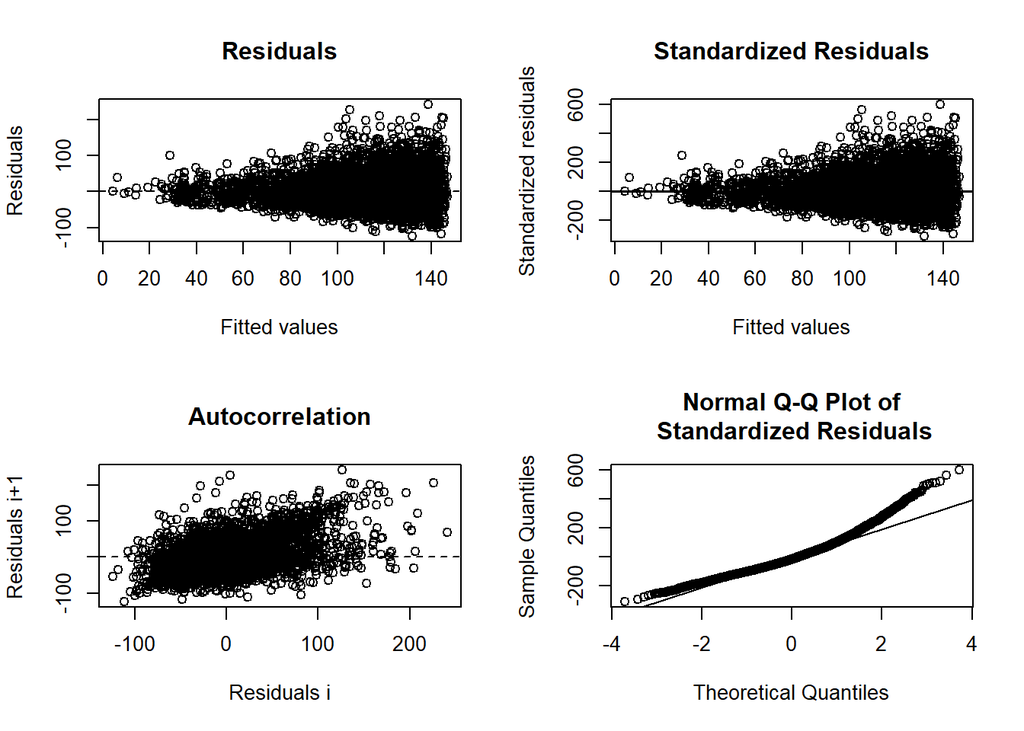

## predict and plot

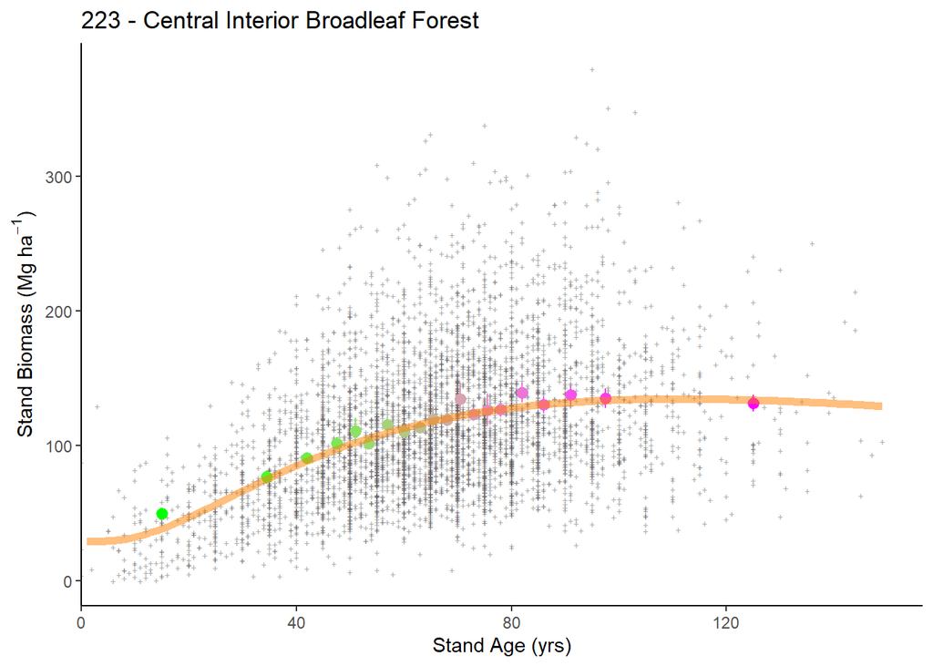

## plotting 2

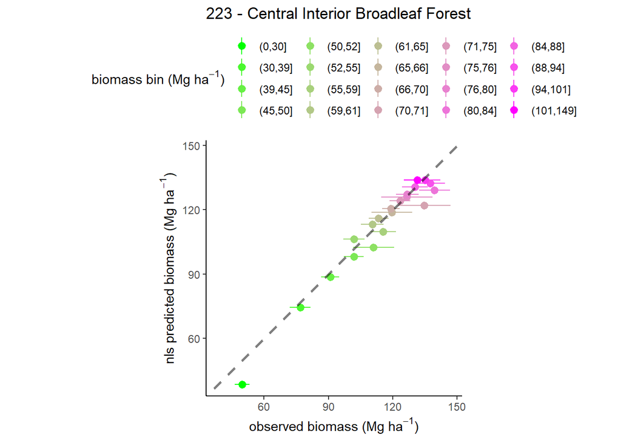

# 231 - Southeastern Mixed Forest

## model selection 1

```
## Analysis of Variance Table
##
## Model 1: B_plt_t2_MgHa ~ (1 + (MEASTIME_t2 - 1990) * ge/100) * (a + b * exp(-((log(STDAGE_t2/c))/d)^2))
## Model 2: B_plt_t2_MgHa ~ (1 + (MEASTIME_t2 - 1990) * ge/100) * (1 + phi * DeltaPDSI) * (a + b * exp(-((log(STDAGE_t2/c))/d)^2))
## Model 3: B_plt_t2_MgHa ~ (1 + (MEASTIME_t2 - 1990) * ge/100) * (1 + phi * DeltaPDSI) * (1 - alpha * B_L_prop) * (a + b * exp(-((log(STDAGE_t2/c))/d)^2))
##   Res.Df Res.Sum Sq Df Sum Sq F value Pr(>F)
## 1   5944     1181.0
## 2   5943     1181.0  1  0.000    0.00      1
## 3   5942     1127.7  1 53.259  280.63 <2e-16 ***
## ---
## Signif. codes:  0 '***' 0.001 '**' 0.01 '*' 0.05 '.' 0.1 ' ' 1
##   model      AIC
## 1     1 64190.96
## 2     2 64192.96
## 3     3 63920.43
```

```
##
## Formula: B_plt_t2_MgHa ~ (1 + (MEASTIME_t2 - 1990) * ge/100) * (1 + phi *
##     DeltaPDSI) * (1 - alpha * B_L_prop) * (a + b * exp(-((log(STDAGE_t2/c))/d)^2))
##
## Parameters:
##        Estimate Std. Error t value Pr(>|t|)
## ge    1.561e+00  1.678e-01   9.304  < 2e-16 ***
## phi   0.000e+00  5.603e-03   0.000 1.000000
## alpha 8.528e-01  4.804e-02  17.752  < 2e-16 ***
## a     9.325e+00  2.678e+00   3.482 0.000501 ***
## b     1.469e+02  1.137e+01  12.918  < 2e-16 ***
## c     1.890e+02  3.545e+01   5.330 1.02e-07 ***
## d     2.136e+00  1.597e-01  13.373  < 2e-16 ***
## ---
## Signif. codes:  0 '***' 0.001 '**' 0.01 '*' 0.05 '.' 0.1 ' ' 1
##
## Residual standard error: 0.4356 on 5942 degrees of freedom
##
## Algorithm "port", convergence message: relative convergence (4)
##   (3 observations deleted due to missingness)
```

### summary

- simple model: fits
- phi model: fits
- phi-alpha model: fits

## plot residuals

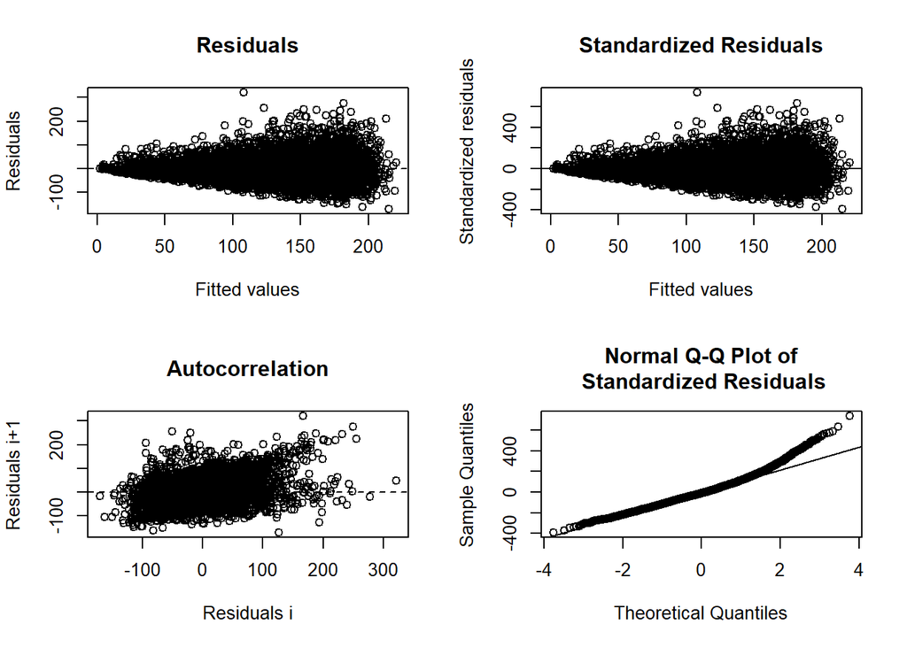

## predict and plot

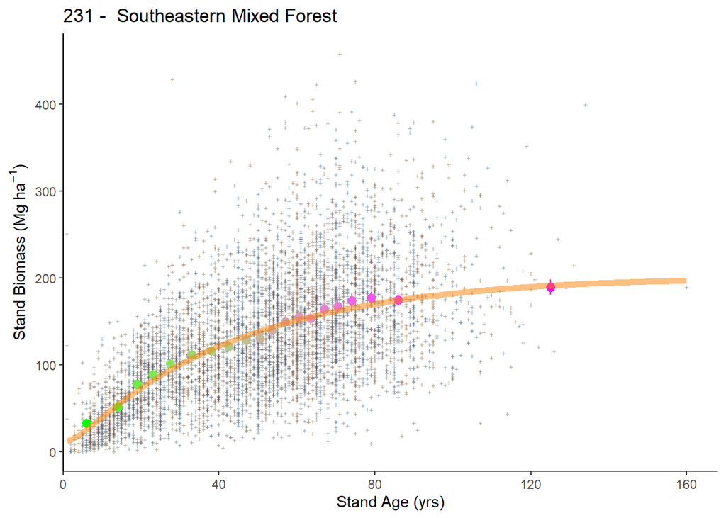

## plotting 2

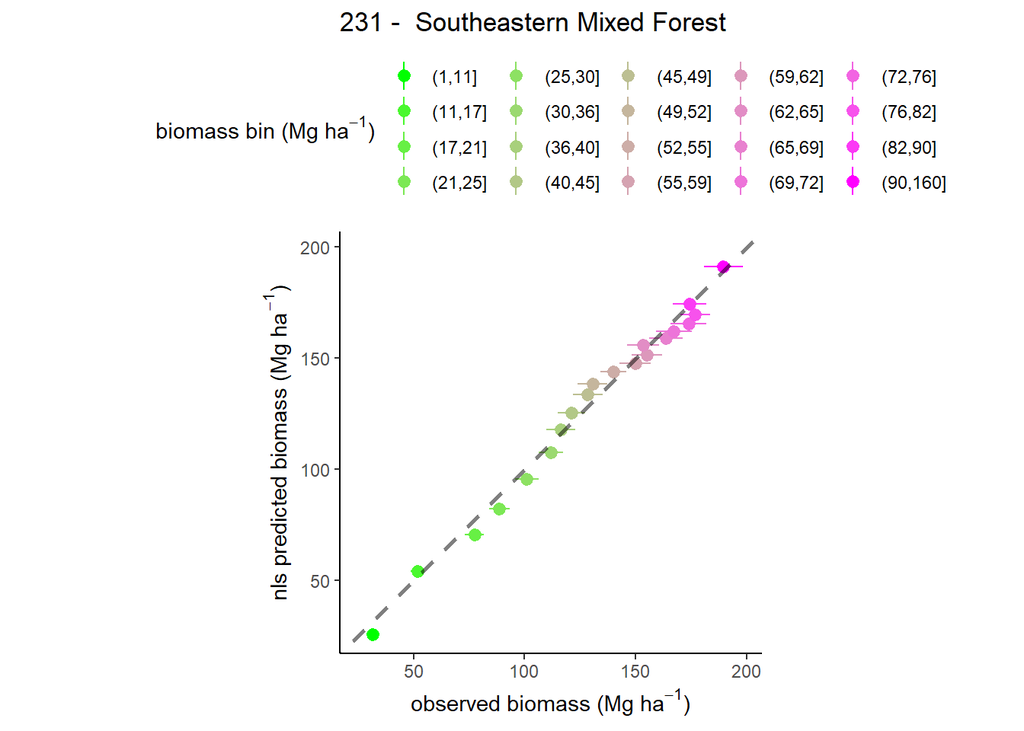

# 232 - Outer Coastal Plain Mixed Forest

## model selection 1

```
## Analysis of Variance Table
##
## Model 1: B_plt_t2_MgHa ~ (1 + (MEASTIME_t2 - 1990) * ge/100) * (a + b * exp(-((log(STDAGE_t2/c))/d)^2))
## Model 2: B_plt_t2_MgHa ~ (1 + (MEASTIME_t2 - 1990) * ge/100) * (1 + phi * DeltaPDSI) * (a + b * exp(-((log(STDAGE_t2/c))/d)^2))
## Model 3: B_plt_t2_MgHa ~ (1 + (MEASTIME_t2 - 1990) * ge/100) * (1 + phi * DeltaPDSI) * (1 - alpha * B_L_prop) * (a + b * exp(-((log(STDAGE_t2/c))/d)^2))
##   Res.Df Res.Sum Sq Df Sum Sq  F value    Pr(>F)
## 1   6113     2021.5
## 2   6112     2018.7  1  2.803   8.4862  0.003592 **
## 3   6111     1932.6  1 86.043 272.0690 < 2.2e-16 ***
## ---
## Signif. codes:  0 '***' 0.001 '**' 0.01 '*' 0.05 '.' 0.1 ' ' 1
##   model      AIC
## 1     1 68217.27
## 2     2 68210.78
## 3     3 67946.29
```

```
##
## Formula: B_plt_t2_MgHa ~ (1 + (MEASTIME_t2 - 1990) * ge/100) * (1 + phi *
##     DeltaPDSI) * (1 - alpha * B_L_prop) * (a + b * exp(-((log(STDAGE_t2/c))/d)^2))
##
## Parameters:
##        Estimate Std. Error t value Pr(>|t|)
## ge    1.008e+00  1.854e-01   5.439 5.58e-08 ***
## phi   1.865e-02  7.171e-03   2.601  0.00931 **
## alpha 8.298e-01  4.688e-02  17.700  < 2e-16 ***
## a     1.587e+01  2.740e+00   5.794 7.22e-09 ***
## b     1.434e+02  1.140e+01  12.580  < 2e-16 ***
## c     1.660e+02  2.874e+01   5.774 8.14e-09 ***
## d     1.906e+00  1.495e-01  12.747  < 2e-16 ***
## ---
## Signif. codes:  0 '***' 0.001 '**' 0.01 '*' 0.05 '.' 0.1 ' ' 1
##
## Residual standard error: 0.5624 on 6111 degrees of freedom
##
## Algorithm "port", convergence message: relative convergence (4)
##   (2 observations deleted due to missingness)
```

### summary

- simple model: fits
- phi model: fits
- phi-alpha model: fits

## plot residuals

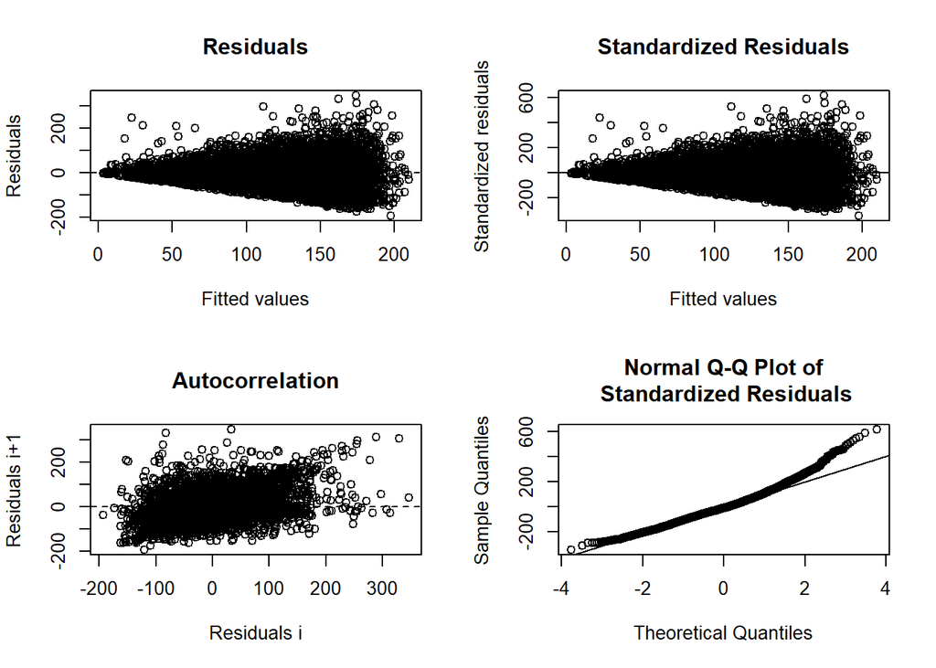

## predict and plot

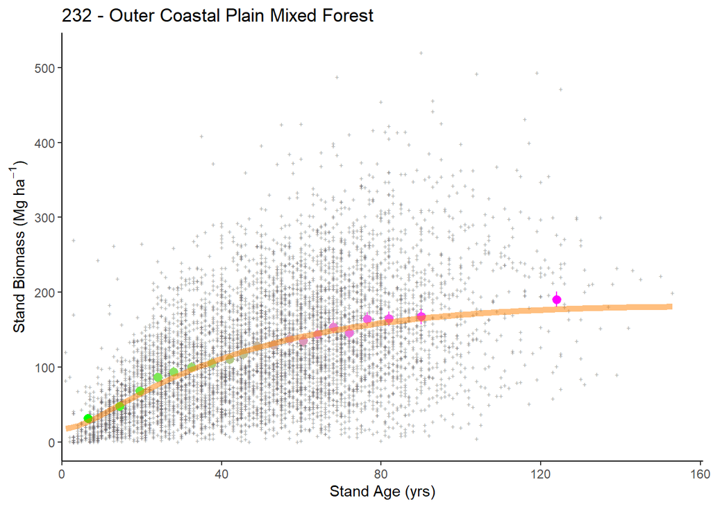

## plotting 2

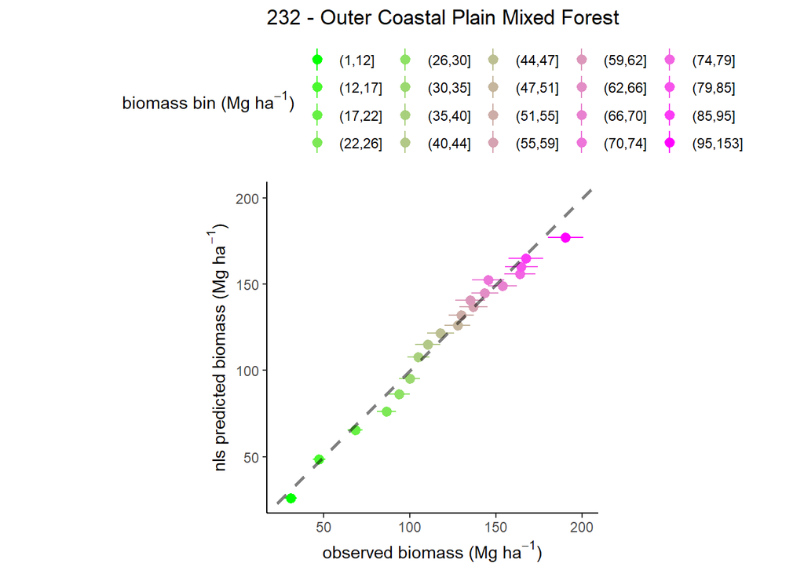

# 234 - Lower Mississippi Riverine Forest

## model selection 1

```
## Error in nls(f_ln_1, data = G_234, start = c(ge = ge.start, a = a.start,  :
##   Convergence failure: iteration limit reached without convergence (10)
## Error in nls(f_ln_2, data = G_234, start = c(ge = ge.start, phi = phi.start,  :
##   Convergence failure: iteration limit reached without convergence (10)
## Error in nls(f_ln_3, data = G_234, start = c(ge = ge.start, phi = phi.start,  :
##   Convergence failure: iteration limit reached without convergence (10)
##   model AIC
## 1     1  NA
## 2     2  NA
## 3     3  NA
```

```
## Error in get(paste("nls_234.", Mod.Sel1, sep = "")) :
##   object 'nls_234.' not found
```

### summary

- simple model: does not fit
- phi model: does not fit
- phi-alpha model: does not fit

## plot residuals

```
## [1] "cannot plot residuals"
```

## predict and plot

```
## [1] "cannot plot data with prediction"
```

## plotting 2

```
## [1] "cannot plot observed vs. predicted"
```

# 242 - Pacific Lowland Mixed Forest

## model selection 1

```
## Error in if (any(nEQ <- vNms != make.names(vNms))) vNms[nEQ] <- paste0("`",  :
##   missing value where TRUE/FALSE needed
## Error in if (any(nEQ <- vNms != make.names(vNms))) vNms[nEQ] <- paste0("`",  :
##   missing value where TRUE/FALSE needed
## Error in if (any(nEQ <- vNms != make.names(vNms))) vNms[nEQ] <- paste0("`",  :
##   missing value where TRUE/FALSE needed
##   model AIC
## 1     1  NA
## 2     2  NA
## 3     3  NA
```

```
## Error in get(paste("nls_242.", Mod.Sel1, sep = "")) :
##   object 'nls_242.' not found
```

### summary

- simple model: does not fit
- phi model: does not fit
- phi-alpha model: does not fit

## plot residuals

```
## [1] "cannot plot residuals"
```

## predict and plot

```
## [1] "cannot plot data with prediction"
```

## plotting 2

```
## [1] "cannot plot observed vs. predicted"
```

# 251 - Prairie Parkland (Temperate)

## model selection 1

```
## Analysis of Variance Table
##
## Model 1: B_plt_t2_MgHa ~ (1 + (MEASTIME_t2 - 1990) * ge/100) * (a + b * exp(-((log(STDAGE_t2/c))/d)^2))
## Model 2: B_plt_t2_MgHa ~ (1 + (MEASTIME_t2 - 1990) * ge/100) * (1 + phi * DeltaPDSI) * (a + b * exp(-((log(STDAGE_t2/c))/d)^2))
## Model 3: B_plt_t2_MgHa ~ (1 + (MEASTIME_t2 - 1990) * ge/100) * (1 + phi * DeltaPDSI) * (1 - alpha * B_L_prop) * (a + b * exp(-((log(STDAGE_t2/c))/d)^2))
##   Res.Df Res.Sum Sq Df Sum Sq F value    Pr(>F)
## 1   1106     230.20
## 2   1105     230.20  1  0.000   0.000         1
## 3   1104     220.15  1 10.057  50.433 2.205e-12 ***
## ---
## Signif. codes:  0 '***' 0.001 '**' 0.01 '*' 0.05 '.' 0.1 ' ' 1
##   model      AIC
## 1     1 11531.14
## 2     2 11533.14
## 3     3 11485.51
```

```
##
## Formula: B_plt_t2_MgHa ~ (1 + (MEASTIME_t2 - 1990) * ge/100) * (1 + phi *
##     DeltaPDSI) * (1 - alpha * B_L_prop) * (a + b * exp(-((log(STDAGE_t2/c))/d)^2))
##
## Parameters:
##        Estimate Std. Error t value Pr(>|t|)
## ge      0.43264    0.40923   1.057   0.2907
## phi     0.00000    0.01516   0.000   1.0000
## alpha   0.76994    0.10109   7.617 5.58e-14 ***
## a      22.11432   10.47210   2.112   0.0349 *
## b     100.47693   15.60612   6.438 1.80e-10 ***
## c     121.86322   20.97600   5.810 8.18e-09 ***
## d       1.36306    0.24852   5.485 5.13e-08 ***
## ---
## Signif. codes:  0 '***' 0.001 '**' 0.01 '*' 0.05 '.' 0.1 ' ' 1
##
## Residual standard error: 0.4466 on 1104 degrees of freedom
##
## Algorithm "port", convergence message: relative convergence (4)
##   (1 observation deleted due to missingness)
```

### summary

- simple model: fits
- phi model: fits
- phi-alpha model: fits

## plot residuals

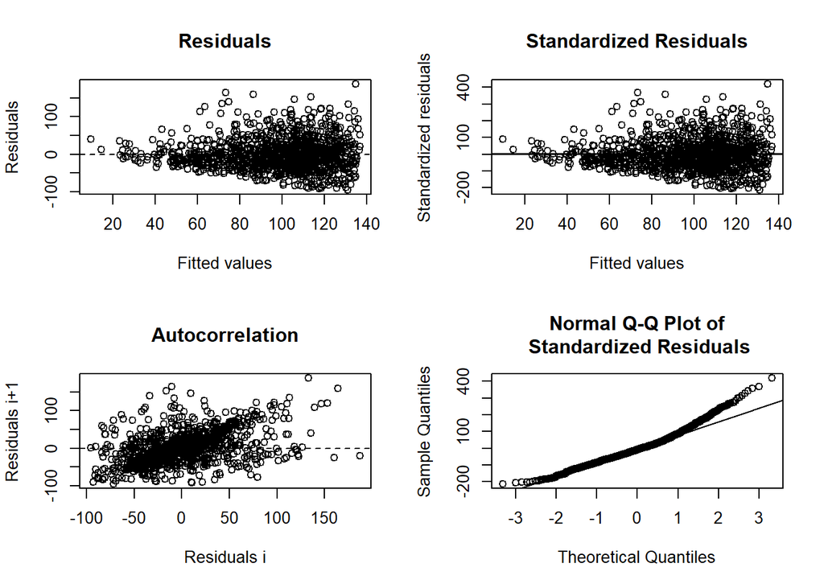

```
##
## ------
##  Shapiro-Wilk normality test
##
## data:  stdres
## W = 0.97015, p-value = 2.372e-14
##
##
## ------
```

```
##
##  Runs Test
##
## data:  as.factor(run)
## Standard Normal = -12.813, p-value < 2.2e-16
## alternative hypothesis: two.sided
```

## predict and plot

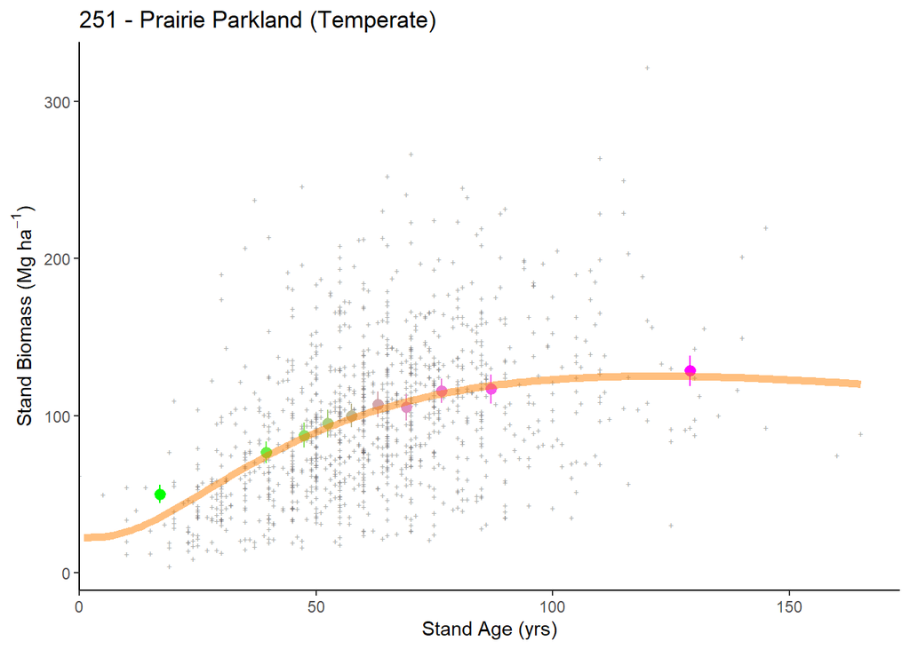

## plotting 2

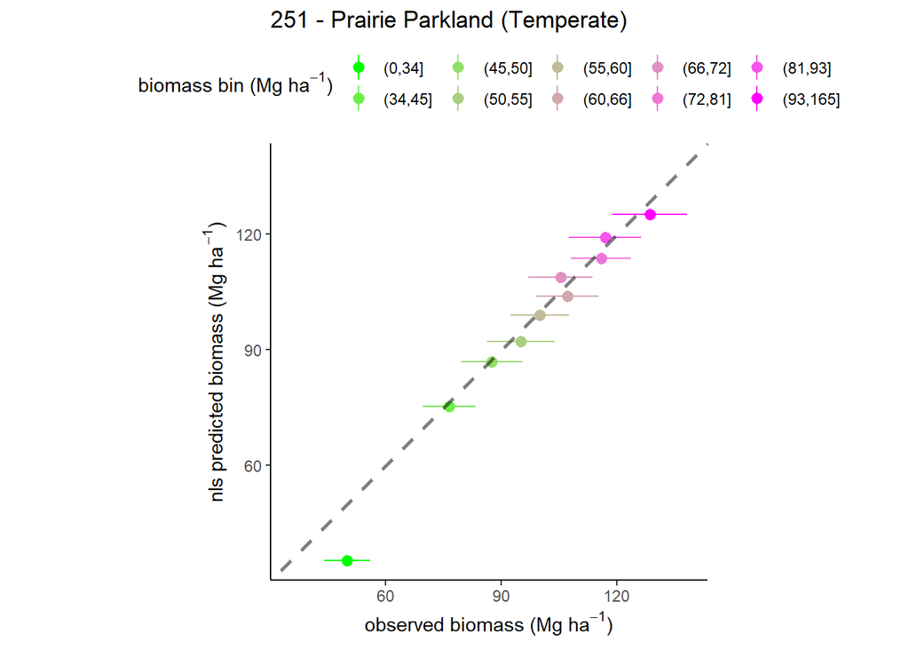

# 255 - Prairie Parkland (Subtropical)

## model selection 1

```
## Analysis of Variance Table
##
## Model 1: B_plt_t2_MgHa ~ (1 + (MEASTIME_t2 - 1990) * ge/100) * (a + b * exp(-((log(STDAGE_t2/c))/d)^2))
## Model 2: B_plt_t2_MgHa ~ (1 + (MEASTIME_t2 - 1990) * ge/100) * (1 + phi * DeltaPDSI) * (a + b * exp(-((log(STDAGE_t2/c))/d)^2))
## Model 3: B_plt_t2_MgHa ~ (1 + (MEASTIME_t2 - 1990) * ge/100) * (1 + phi * DeltaPDSI) * (1 - alpha * B_L_prop) * (a + b * exp(-((log(STDAGE_t2/c))/d)^2))
##   Res.Df Res.Sum Sq Df Sum Sq F value   Pr(>F)
## 1    376     118.56
## 2    375     118.55  1 0.0059  0.0187   0.8912
## 3    374     109.58  1 8.9706 30.6172 5.92e-08 ***
## ---
## Signif. codes:  0 '***' 0.001 '**' 0.01 '*' 0.05 '.' 0.1 ' ' 1
##   model      AIC
## 1     1 3883.422
## 2     2 3885.403
## 3     3 3857.424
```

```
##
## Formula: B_plt_t2_MgHa ~ (1 + (MEASTIME_t2 - 1990) * ge/100) * (1 + phi *
##     DeltaPDSI) * (1 - alpha * B_L_prop) * (a + b * exp(-((log(STDAGE_t2/c))/d)^2))
##
## Parameters:
##       Estimate Std. Error t value Pr(>|t|)
## ge    -0.00669    0.48987  -0.014 0.989111
## phi    0.00000    0.03935   0.000 1.000000
## alpha  0.89789    0.14590   6.154 1.94e-09 ***
## a     18.99235    4.92985   3.853 0.000138 ***
## b     75.68431   10.33986   7.320 1.53e-12 ***
## c     56.02016    5.42152  10.333  < 2e-16 ***
## d      1.01947    0.14907   6.839 3.26e-11 ***
## ---
## Signif. codes:  0 '***' 0.001 '**' 0.01 '*' 0.05 '.' 0.1 ' ' 1
##
## Residual standard error: 0.5413 on 374 degrees of freedom
##
## Algorithm "port", convergence message: relative convergence (4)
##   (1 observation deleted due to missingness)
```

### summary

- simple model: fits
- phi model: fits
- phi-alpha model: fits

## plot residuals

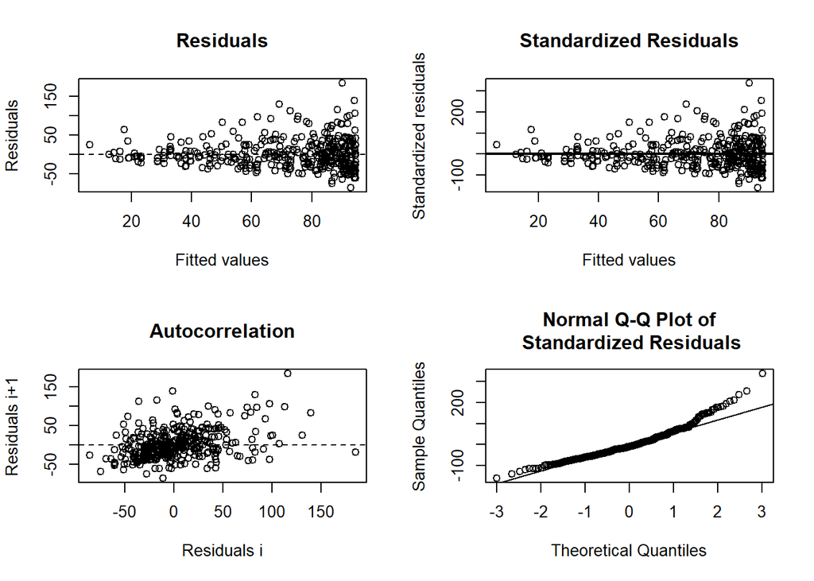

```
##
## ------
##  Shapiro-Wilk normality test
##
## data:  stdres
## W = 0.94654, p-value = 1.688e-10
##
##
## ------
```

```
##
##  Runs Test
##
## data:  as.factor(run)
## Standard Normal = -6.9098, p-value = 4.855e-12
## alternative hypothesis: two.sided
```

## predict and plot

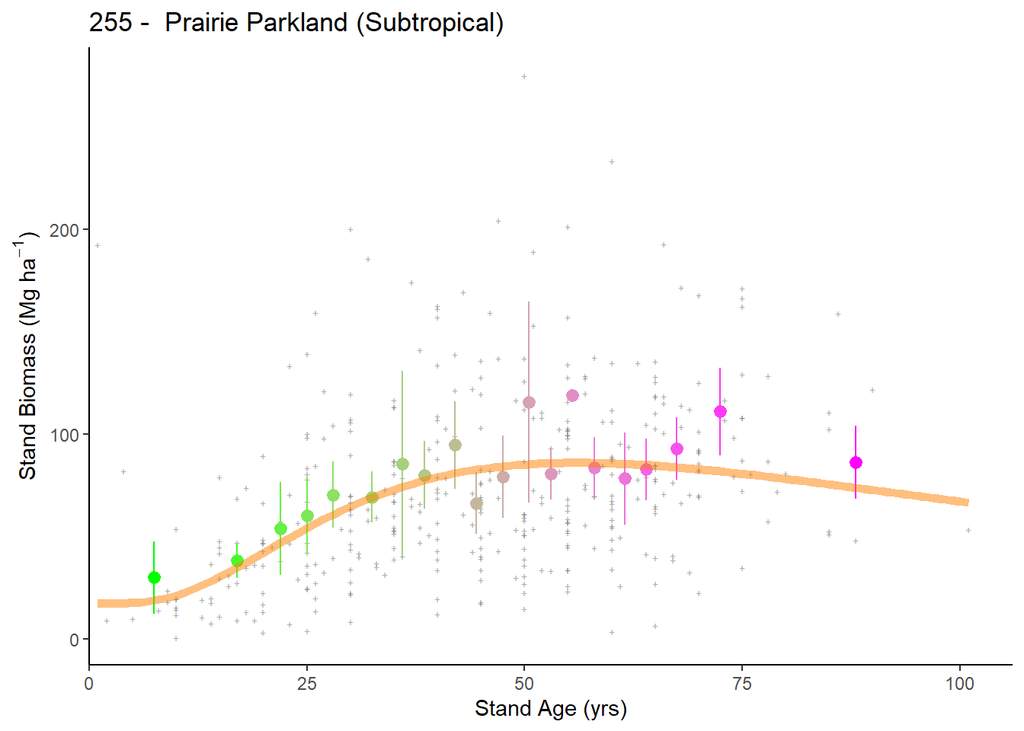

## plotting 2

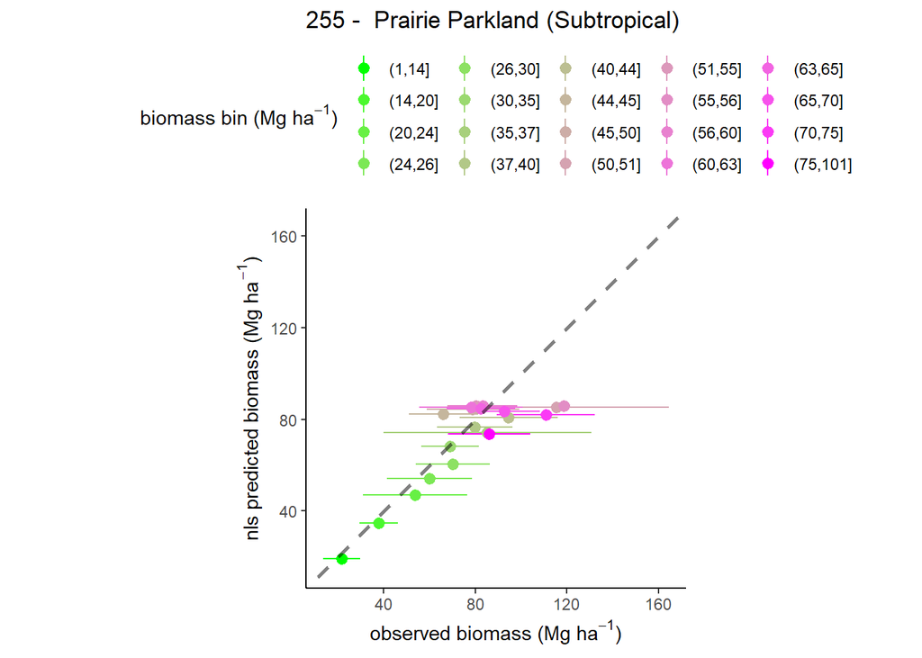

# 261 - California Coastal Chaparral Forest and Shrub

## model selection 1

```
## Error in if (any(nEQ <- vNms != make.names(vNms))) vNms[nEQ] <- paste0("`",  :
##   missing value where TRUE/FALSE needed
## Error in if (any(nEQ <- vNms != make.names(vNms))) vNms[nEQ] <- paste0("`",  :
##   missing value where TRUE/FALSE needed
## Error in if (any(nEQ <- vNms != make.names(vNms))) vNms[nEQ] <- paste0("`",  :
##   missing value where TRUE/FALSE needed
##   model AIC
## 1     1  NA
## 2     2  NA
## 3     3  NA
```

```
## Error in get(paste("nls_261.", Mod.Sel1, sep = "")) :
##   object 'nls_261.' not found
```

### summary

- simple model: does not fit
- phi model: does not fit
- phi-alpha model: does not fit
- unable to fit model (only 64 observations)

## plot residuals

```
## [1] "cannot plot residuals"
```

## predict and plot

```
## [1] "cannot plot data with prediction"
```

## plotting 2

```
## [1] "cannot plot observed vs. predicted"
```

# 262 - California Dry Steppe

## model selection 1

```
## Error in if (any(nEQ <- vNms != make.names(vNms))) vNms[nEQ] <- paste0("`",  :
##   missing value where TRUE/FALSE needed
## Error in if (any(nEQ <- vNms != make.names(vNms))) vNms[nEQ] <- paste0("`",  :
##   missing value where TRUE/FALSE needed
## Error in if (any(nEQ <- vNms != make.names(vNms))) vNms[nEQ] <- paste0("`",  :
##   missing value where TRUE/FALSE needed
##   model AIC
## 1     1  NA
## 2     2  NA
## 3     3  NA
```

```
## Error in get(paste("nls_262.", Mod.Sel1, sep = "")) :
##   object 'nls_262.' not found
```

### summary

- simple model: does not fit
- phi model: does not fit
- phi-alpha model: does not fit
- unable to fit model (0 observations)

## plot residuals

```
## [1] "cannot plot residuals"
```

## predict and plot

```
## [1] "cannot plot data with prediction"
```

## plotting 2

```
## [1] "cannot plot observed vs. predicted"
```

# 263 - California Coastal Steppe - Mixed Forest and Redwood Forest

## model selection 1

```
## Error in if (any(nEQ <- vNms != make.names(vNms))) vNms[nEQ] <- paste0("`",  :
##   missing value where TRUE/FALSE needed
## Error in if (any(nEQ <- vNms != make.names(vNms))) vNms[nEQ] <- paste0("`",  :
##   missing value where TRUE/FALSE needed
## Error in if (any(nEQ <- vNms != make.names(vNms))) vNms[nEQ] <- paste0("`",  :
##   missing value where TRUE/FALSE needed
##   model AIC
## 1     1  NA
## 2     2  NA
## 3     3  NA
```

```
## Error in get(paste("nls_263.", Mod.Sel1, sep = "")) :
##   object 'nls_263.' not found
```

### summary

- simple model: does not fit
- phi model: does not fit
- phi-alpha model: does not fit

## plot residuals

```
## [1] "cannot plot residuals"
```

## predict and plot

```
## [1] "cannot plot data with prediction"
```

## plotting 2

```
## [1] "cannot plot observed vs. predicted"
```

# 313 - Colorado Plateau Semi-Desert

## model selection 1

```
## Error in if (any(nEQ <- vNms != make.names(vNms))) vNms[nEQ] <- paste0("`",  :
##   missing value where TRUE/FALSE needed
## Error in if (any(nEQ <- vNms != make.names(vNms))) vNms[nEQ] <- paste0("`",  :
##   missing value where TRUE/FALSE needed
## Error in if (any(nEQ <- vNms != make.names(vNms))) vNms[nEQ] <- paste0("`",  :
##   missing value where TRUE/FALSE needed
##   model AIC
## 1     1  NA
## 2     2  NA
## 3     3  NA
```

```
## Error in get(paste("nls_313.", Mod.Sel1, sep = "")) :
##   object 'nls_313.' not found
```

### summary

- simple model: does not fit
- phi model: does not fit
- phi-alpha model: does not fit

## plot residuals

```
## [1] "cannot plot residuals"
```

## predict and plot

```
## [1] "cannot plot data with prediction"
```

## plotting 2

```
## [1] "cannot plot observed vs. predicted"
```

# 315 - Southwest Plateau and Plains Dry Steppe and Shrub

## model selection 1

### summary

- simple model: does not fit
- phi model: does not fit
- phi-alpha model: does not fit

## plot residuals

```
## [1] "cannot plot residuals"
```

## predict and plot

```
## [1] "cannot plot data with prediction"
```

## plotting 2

```
## [1] "cannot plot observed vs. predicted"
```

# 321 - Chihuahuan Semi-Desert

## model selection 1

### summary

- simple model: does not fit
- phi model: does not fit
- phi-alpha model: does not fit

## plot residuals

```
## [1] "cannot plot residuals"
```

## predict and plot

```
## [1] "cannot plot data with prediction"
```

## plotting 2

```
## [1] "cannot plot observed vs. predicted"
```

# 322 - American Semidesert and Desert

## model selection 1

### summary

- simple model: does not fit
- phi model: does not fit
- phi-alpha model: does not fit

## plot residuals

```
## [1] "cannot plot residuals"
```

## predict and plot

```
## [1] "cannot plot data with prediction"
```

## plotting 2

```
## [1] "cannot plot observed vs. predicted"
```

- Cannot fit model
- not enough data (only 3 observations)

# 331 - Great Plains/Palouse Dry Steppe

## model selection 1

```
## Error in nls(f_ln_1, data = G_331, start = c(ge = ge.start, a = a.start,  :
##   Convergence failure: singular convergence (7)
## Error in nls(f_ln_2, data = G_331, start = c(ge = ge.start, phi = phi.start,  :
##   Convergence failure: singular convergence (7)
## Error in nls(f_ln_3, data = G_331, start = c(ge = ge.start, phi = phi.start,  :
##   Convergence failure: singular convergence (7)
##   model AIC
## 1     1  NA
## 2     2  NA
## 3     3  NA
```

```
## Error in get(paste("nls_331.", Mod.Sel1, sep = "")) :
##   object 'nls_331.' not found
```

### summary

- simple model: does not fit
- phi model: does not fit
- phi-alpha model: does not fit

## plot residuals

```
## [1] "cannot plot residuals"
```

## predict and plot

```
## [1] "cannot plot data with prediction"
```

## plotting 2

```
## [1] "cannot plot observed vs. predicted"
```

- Cannot fit model

# 332 - Great Plains Steppe

## model selection 1

### summary

- simple model: does not fit
- phi model: does not fit
- phi-alpha model: does not fit

## plot residuals

```
## [1] "cannot plot residuals"
```

## predict and plot

```
## [1] "cannot plot data with prediction"
```

## plotting 2

```
## [1] "cannot plot observed vs. predicted"
```

# 341 - Nevada-Utah Mountains Semi-Desert - Coniferous Forest - Alpine Meadow

## model selection 1

### summary

- simple model: does not fit
- phi model: does not fit
- phi-alpha model: does not fit

## plot residuals

```
## [1] "cannot plot residuals"
```

- model not fitted because only 62 observations

## predict and plot

```
## [1] "cannot plot data with prediction"
```

## plotting 2

```
## [1] "cannot plot observed vs. predicted"
```

# 342 - Intermountain Semi-Desert

## model selection 1

### summary

- simple model: does not fit
- phi model: does not fit
- phi-alpha model: does not fit

## plot residuals

```
## [1] "cannot plot residuals"
```

## predict and plot

```
## [1] "cannot plot data with prediction"
```

## plotting 2

```
## [1] "cannot plot observed vs. predicted"
```

# 411 - Everglades

## model selection 1

### summary

- simple model: does not fit
- phi model: does not fit
- phi-alpha model: does not fit

## plot residuals

```
## [1] "cannot plot residuals"
```

## predict and plot

```
## [1] "cannot plot data with prediction"
```

## plotting 2

```
## [1] "cannot plot observed vs. predicted"
```

# M211 - Adirondack-New England Mixed forest - Coniferous Forest - Alpine Meadow

## model selection 1

```
## Analysis of Variance Table
##
## Model 1: B_plt_t2_MgHa ~ (1 + (MEASTIME_t2 - 1990) * ge/100) * (a + b * exp(-((log(STDAGE_t2/c))/d)^2))
## Model 2: B_plt_t2_MgHa ~ (1 + (MEASTIME_t2 - 1990) * ge/100) * (1 + phi * DeltaPDSI) * (a + b * exp(-((log(STDAGE_t2/c))/d)^2))
## Model 3: B_plt_t2_MgHa ~ (1 + (MEASTIME_t2 - 1990) * ge/100) * (1 + phi * DeltaPDSI) * (1 - alpha * B_L_prop) * (a + b * exp(-((log(STDAGE_t2/c))/d)^2))
##   Res.Df Res.Sum Sq Df  Sum Sq F value    Pr(>F)
## 1   3942     607.28
## 2   3941     603.82  1  3.4623  22.598 2.068e-06 ***
## 3   3940     576.57  1 27.2435 186.168 < 2.2e-16 ***
## ---
## Signif. codes:  0 '***' 0.001 '**' 0.01 '*' 0.05 '.' 0.1 ' ' 1
##   model      AIC
## 1     1 41787.15
## 2     2 41766.58
## 3     3 41586.36
```

```
##
## Formula: B_plt_t2_MgHa ~ (1 + (MEASTIME_t2 - 1990) * ge/100) * (1 + phi *
##     DeltaPDSI) * (1 - alpha * B_L_prop) * (a + b * exp(-((log(STDAGE_t2/c))/d)^2))
##
## Parameters:
##        Estimate Std. Error t value Pr(>|t|)
## ge    7.405e-01  2.047e-01   3.617 0.000302 ***
## phi   2.909e-02  7.017e-03   4.146 3.46e-05 ***
## alpha 9.473e-01  6.506e-02  14.560  < 2e-16 ***
## a     2.191e+01  3.096e+00   7.077 1.74e-12 ***
## b     1.324e+02  9.027e+00  14.664  < 2e-16 ***
## c     1.598e+02  1.523e+01  10.487  < 2e-16 ***
## d     1.414e+00  9.893e-02  14.296  < 2e-16 ***
## ---
## Signif. codes:  0 '***' 0.001 '**' 0.01 '*' 0.05 '.' 0.1 ' ' 1
##
## Residual standard error: 0.3825 on 3940 degrees of freedom
##
## Algorithm "port", convergence message: relative convergence (4)
##   (1 observation deleted due to missingness)
```

### summary

- simple model: fits
- phi model: fits
- phi-alpha model: fits

## plot residuals

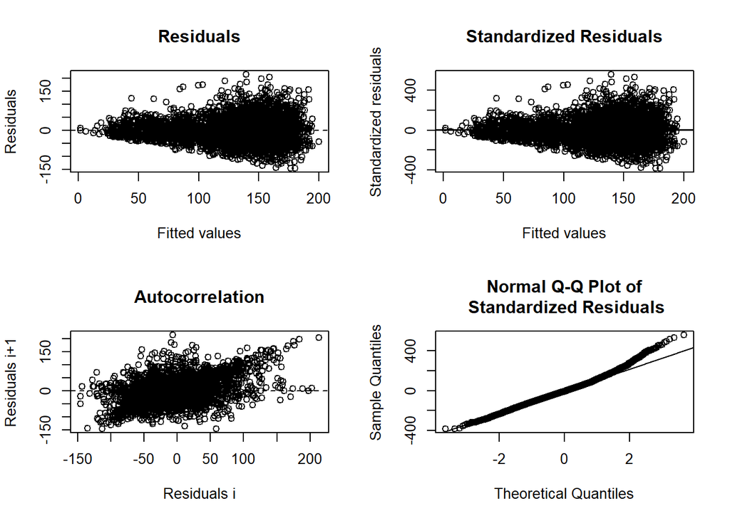

```
##
## ------
##  Shapiro-Wilk normality test
##
## data:  stdres
## W = 0.9883, p-value < 2.2e-16
##
##
## ------
```

```
##
##  Runs Test
##
## data:  as.factor(run)
## Standard Normal = -26.236, p-value < 2.2e-16
## alternative hypothesis: two.sided
```

## predict and plot

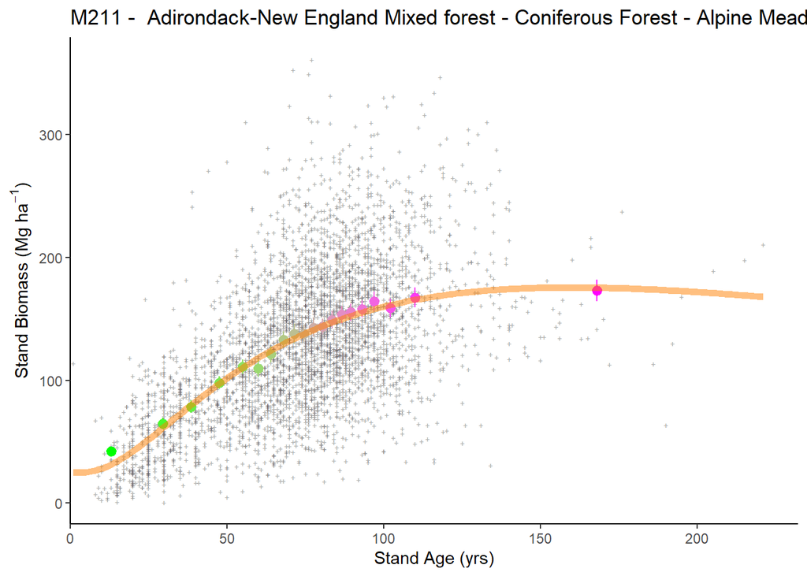

## plotting 2

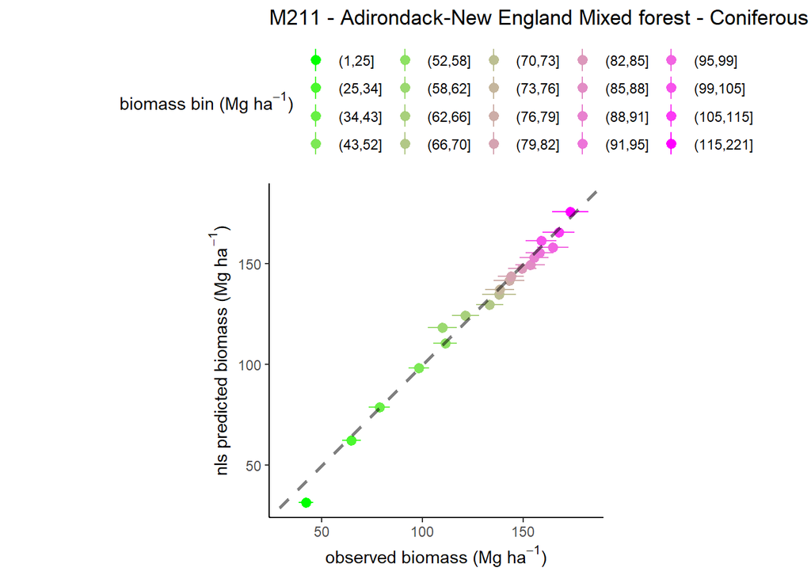

# M221 - Eastern Broadleaf Forest

## model selection 1

```
## Analysis of Variance Table
##
## Model 1: B_plt_t2_MgHa ~ (1 + (MEASTIME_t2 - 1990) * ge/100) * (a + b * exp(-((log(STDAGE_t2/c))/d)^2))
## Model 2: B_plt_t2_MgHa ~ (1 + (MEASTIME_t2 - 1990) * ge/100) * (1 + phi * DeltaPDSI) * (a + b * exp(-((log(STDAGE_t2/c))/d)^2))
## Model 3: B_plt_t2_MgHa ~ (1 + (MEASTIME_t2 - 1990) * ge/100) * (1 + phi * DeltaPDSI) * (1 - alpha * B_L_prop) * (a + b * exp(-((log(STDAGE_t2/c))/d)^2))
##   Res.Df Res.Sum Sq Df Sum Sq F value Pr(>F)
## 1   4544     712.26
## 2   4543     712.26  1  0.000    0.00      1
## 3   4542     681.89  1 30.367  202.27 <2e-16 ***
## ---
## Signif. codes:  0 '***' 0.001 '**' 0.01 '*' 0.05 '.' 0.1 ' ' 1
##   model      AIC
## 1     1 50199.27
## 2     2 50201.27
## 3     3 50005.06
```

```
##
## Formula: B_plt_t2_MgHa ~ (1 + (MEASTIME_t2 - 1990) * ge/100) * (1 + phi *
##     DeltaPDSI) * (1 - alpha * B_L_prop) * (a + b * exp(-((log(STDAGE_t2/c))/d)^2))
##
## Parameters:
##        Estimate Std. Error t value Pr(>|t|)
## ge    9.943e-01  1.558e-01    6.38 1.95e-10 ***
## phi   0.000e+00  5.788e-03    0.00        1
## alpha 9.162e-01  6.121e-02   14.97  < 2e-16 ***
## a     3.676e+01  3.124e+00   11.77  < 2e-16 ***
## b     1.150e+02  4.901e+00   23.47  < 2e-16 ***
## c     1.020e+02  3.996e+00   25.52  < 2e-16 ***
## d     1.200e+00  6.343e-02   18.92  < 2e-16 ***
## ---
## Signif. codes:  0 '***' 0.001 '**' 0.01 '*' 0.05 '.' 0.1 ' ' 1
##
## Residual standard error: 0.3875 on 4542 degrees of freedom
##
## Algorithm "port", convergence message: relative convergence (4)
##   (1 observation deleted due to missingness)
```

### summary

- simple model: fits
- phi model: fits
- phi-alpha model: fits

## plot residuals

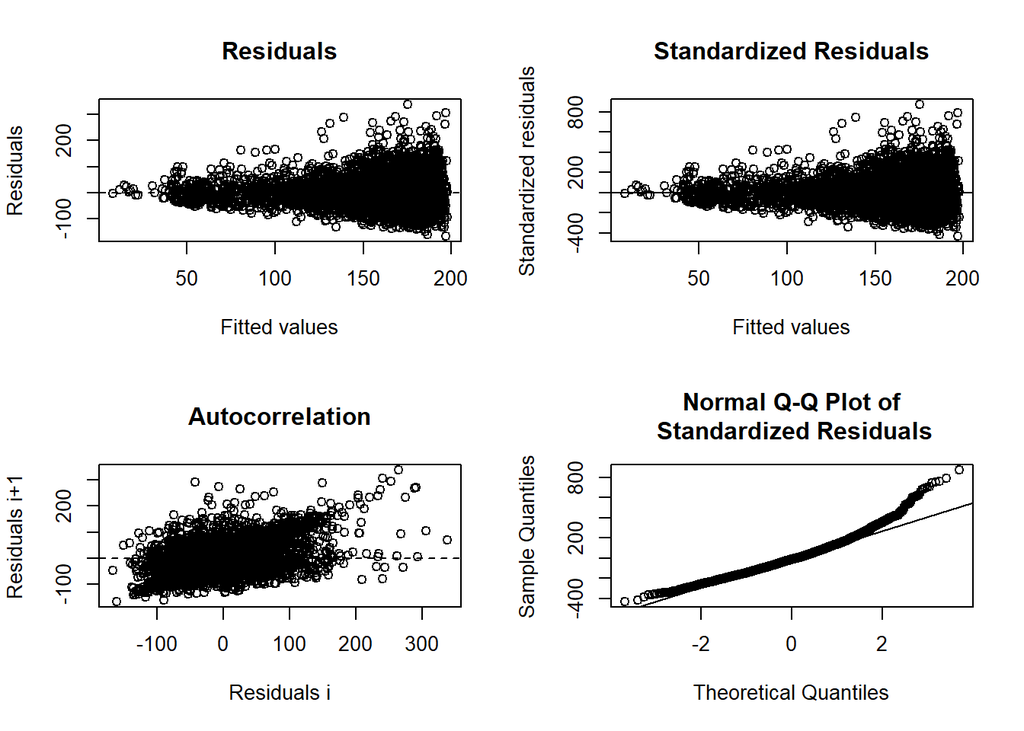

```
##
## ------
##  Shapiro-Wilk normality test
##
## data:  stdres
## W = 0.9696, p-value < 2.2e-16
##
##
## ------
```

```
##
##  Runs Test
##
## data:  as.factor(run)
## Standard Normal = -26.54, p-value < 2.2e-16
## alternative hypothesis: two.sided
```